# HPM R learners - Summer 2020

Last Updated 07/27/2020

This will be the R learners website for the summer! Most all of my resources will be posted here.

Contact: Natalie Smith natsmith@live.unc.edu

## Intro

We will meet regularly on Mondays from 11am-1pm. I’ll spend 1 hour (max) reviewing the topic for that day and the different packages, etc. that are involved. The second hour will be working through examples and is totally optional – you can feel free to work through the examples on your own whenever works for you.

This will be very casual – kids, pets, eating are all okay! Interrupt me anytime via chat or audio to ask questions and *please* tell me to slow down if necessary.

#### First month of topics:

- June 1: Workflows in R - projects, scripts, and markdown files. Integration with GitHub – what is git & why you should use it, and using GitHub pages to make easy-to-access html webpages for your projects!
- June 8: What are R objects, and why do I have to care?
- June 15: Kathleen lead data management introduction
- June 22: Review data management and begin plotting
- June 29: Continue plotting!
- July 6: More data management - joining/merging, transposing.
- July 13: Descriptive statistics
- July 20: Modeling - using outside resources
- July 27: Final week! I’ll be online for the usual 11-12ish hour and can review anything, help out with issues, etc.

Some other things that we could have done but did not:

- more advanced R markdown - producing word documents and writing whole papers in R (with numbers in-text, tables, and figures linked to data, etc.)
- writing functions, and applying them efficiently
- personal websites in R using blogdown

#### Meeting times

Some fun data management to wrangle our data into shape for graphing

```r
rusersOrig <- readxl::read_excel(here("data", "R users group list 0527_136PM.xlsx"))

# I had already taken a manual look at the data before doing this
# also when I was building this code I was outputting new datasets in between steps
# so I could see how the sample size changed, etc.
# then I put it all together at the end into one big data step
# %>% is the pipe operator https://r4ds.had.co.nz/pipes.html
rusers <- rusersOrig %>%

  # Because of the way Qualtrics data imports, there is an extra row here with the variable labels
  # Get rid of it by saying 'keep all rows that have a StartDate NOT EQUAL to "Start Date"
  # filter() keeps rows that return TRUE for a given condition(s)
  filter(StartDate != "Start Date") %>%


  # select() keeps the variables that I want
  # you can rename on the fly newVar = oldVar
  # the other option is the rename() function
  select(morning = Q2_1,
         midday = Q2_2,
         afternoon = Q2_3,
         evening = Q2_4) %>%

  # Since I deidentified the data, want to make an ID so I can transpose
  # rownames_to_column() takes the sequential rowname and makes an ID var
  # Lots of other ways to do this, could make a random number, etc.
  # This is really only necessary for the pivoting.
  rownames_to_column(var="ID") %>%

  # Now I want to pivot to long format for easier data processing
  # this takes the 4 time variables and transposes them
  # now I only have to work on one column, rather than 4

  # start:
  # ID morning midday afternoon evening
  # end:
  # ID morning mon/tues/etc.
  # ID midday mon/tues/etc.
  # ID afternoon mon/tues/etc.
  # ...
  pivot_longer(cols=c(morning, midday, afternoon, evening),
               names_to = "time",
               values_to = "days") %>%

  # Keep only the rows that have NON-MISSING data for the 'days' column.
  # This exists because some people didn't check any days for a given time
  # (i.e., someone who never wanted to meet in the morning)
  filter(!is.na(days)) %>%

  # mutate() is the wrapper for new variables
  # within the mutate() function, you can make lots of variables.
  # newVar = thing to make newvar,
  # str_detect() is part of the stringr package. It returns a Boolean TRUE/FALSE
  # variable that is TRUE if the given string was detected, and FALSE if not
  # 5 new variables, each a boolean with info about whether or not that person can meet on that day
  mutate(mon = str_detect(days, "Monday"),
         tues = str_detect(days, "Tuesday"),
         wed = str_detect(days, "Wednesday"),
         thurs = str_detect(days, "Thursday"),
         fri = str_detect(days, "Friday")) %>%

  # select() can also drop variables if you put the - in front
  # dropping ID and the original 'days' variable.
  # I now have info fromd ays in the mon/tues/wed/thurs/fri variables
  select(-ID, -days) %>%


  # Another transpose/pivot
  # want to keep the 'day' information in one column
  # so now the columns of this data will be:
  # time day tf
  pivot_longer(cols=c(mon, tues, wed, thurs, fri),
               names_to = "day",
               values_to = "tf") %>%

  # only keep the days that are TRUE
  # this will allow us to count the total number of TRUEs per time/day
  filter(tf==TRUE) %>%

  # since we have kept TRUEs only, don't need that var anymore
  select(-tf) %>%

  # group_by() gets your data ready to calculate numbers by a given grouping
  # for every combination of time and day
  group_by(time, day, .groups="keep") %>%

  # summarise() is used after group by to create summary stats
  # you can also use things like mean(), sum(), etc.
  # count the number of times that combination occurs using n()
  summarise(count = n()) %>%

  # get rid of the grouping (other functions won't work if you keep it implicitly grouped)
  # our dataset now has one row for every time-day combination
  # and a count of how many times that combination occurred
  ungroup() %>%

  # making factor variables that look nicer for display purposes
  # factor() takes a given variable and allows you to define the levels
  # and associate a label with each level
  mutate(time = factor(time,
                       levels = c("morning", "midday", "afternoon", "evening"),
                       labels = c("morning" = "Morning \n 8a-11a",
                                  "midday" = "Midday \n 11a-1p",
                                  "afternoon" = "Afternoon \n 1p-4p",
                                  "evening" = "Evening \n 4p-6p")),
         day = factor(day,
                      levels = c("mon", "tues", "wed", "thurs", "fri"),
                      labels = c("mon" = "Monday",
                                 "tues" = "Tuesday",
                                 "wed" = "Wednesday",
                                 "thurs" = "Thursday",
                                 "fri" = "Friday")),

         # if_else() statement -- pretty standard
         gt14 = if_else(condition = count>=14,
                        true = 1,
                        false = 0)) %>%

  # arrange() arranges data according to vars
  # factors will be arranged in their order
  # just doing this here to demonstrate
  arrange(time, day)
```

Now let’s make a beautiful graph.

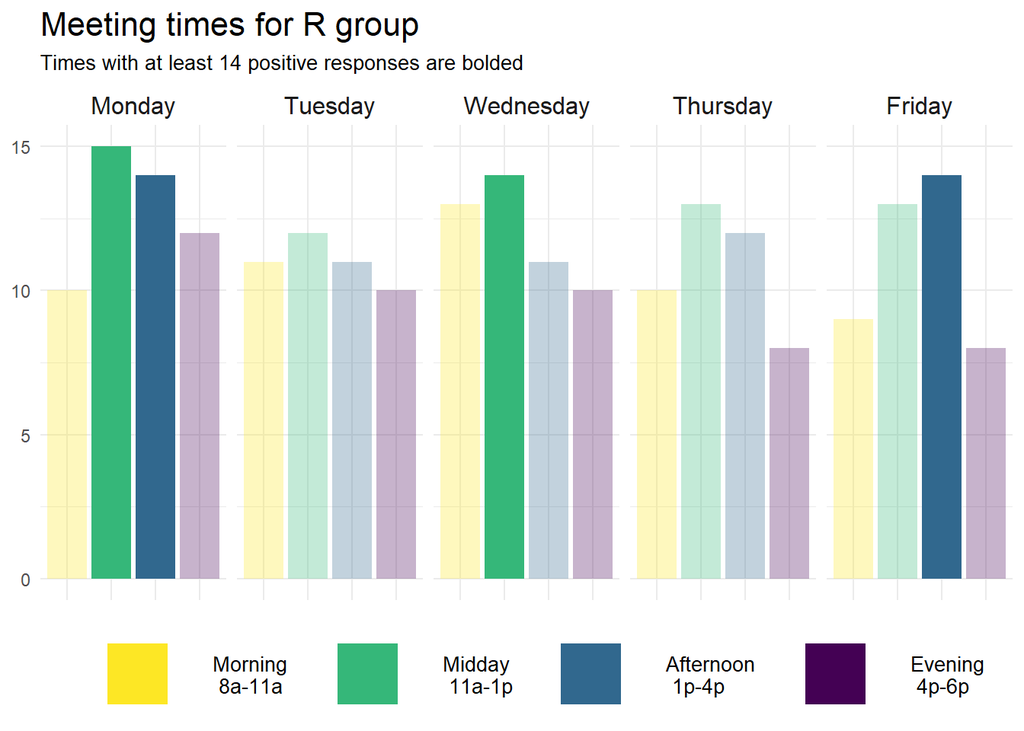

```r
# initialize our plot with the data, and what the x and y axes are
ggplot(data=rusers,
       aes(x=time,
           y=count)) +

  # make a bar chart
  # this will 'inherit' the aesthetics we defined above
  # so, y is the COUNT and x is the TIME
  # fill means that the color for each bar is defined by TIME
  # alpha is the transparency, since I want to bold the times that were given by >= 14 people
  # have to use factor() because ggplot needs to know that there are 2 levels to this variable
  # that's how it will assign transparencies
  # you'll see a little warning from R on using transparencies for a discrete variable
  # I don't get why it has a problem with this. I think it makes sense!
  geom_bar(aes(fill=time, alpha=factor(gt14)),
           stat="identity") +

  # this sets the alpha to be within a given range
  # since there are two values, I think one will be at the low end and one at the high end
  # can tweak this to make it look how you want
  # am not as familiar with alpha
  # also lots of ggplot is tweaking until it looks right
  # just beware that the plot window in RStudio might look different than when you output to png or pdf
  scale_alpha_discrete(range=c(0.3, 1)) +

  # change colors to be the viridis scale (regular ggplot colors are yucky)
  # the _d in the command means for discrete variables
  # direction means that I want to reverse the default ordering of the colors
  scale_fill_viridis_d(direction=-1) +

  # create this barplot separately for each DAY
  # display them in one row
  facet_wrap(~day,
             nrow=1) +

  # get rid of the usual ggplot theme
  # https://ggplot2.tidyverse.org/reference/ggtheme.html
  theme_minimal() +

  # tweak lots of the little theme options
  # there are almost endless options here
  # lots of trial and error
  # help page for ?theme
  theme(legend.position = "bottom", # legend at bottom
        legend.title = element_blank(), # remove legend title
        axis.text.x = element_blank(), # remove axis text (labeled times -- pretty intuitive based on legend)
        axis.title.x = element_blank(), # remove x axis title ('time')
        axis.title.y = element_blank(),  # remove y axis title ('count')
        strip.text = element_text(size=12), # change the font size for the facet titles - Monday, etc.
        plot.title = element_text(size=16), # change the font size for the plot title
        plot.subtitle = element_text(size=10), # change the font size for the subtitle
        legend.text = element_text(size=10), # change the font size in the legend
        legend.spacing.x = unit(0.7, 'cm')) + # space out the legend so it can handle the increased font size and increased square sizes

  # I don't want a legend (guide) for the transparency - will put this in a subtitle
  # making the square boxes of the color legend larger
  guides(alpha=FALSE,
         fill = guide_legend(override.aes = list(size = 12))) +

  # add some informative labels
  labs(title = "Meeting times for R group",
       subtitle = "Times with at least 14 positive responses are bolded")
```

We’re going to go with Mondays from 11am-1pm – this is what the most people wanted!

## Getting started

Two general options for how to access and use R

1. Use R through R studio on your actual computer
   - Download R v4.0.0 [here](http://archive.linux.duke.edu/cran/)
   - Download R studio [here](https://rstudio.com/products/rstudio/download/#download)
2. Use rstudio.cloud without the commitment of installing on your computer. *disclaimer: I don’t know as much / anything about this*
   - Don’t have to download R software and the R studio wrapper
   - Possibly less functional for all the bells and whistles – not sure about GitHub integration, etc. But probably just fine for learning the basics, and much less potential annoyance with installations, etc.
3. *Optional* Download [Git](https://git-scm.com/downloads)
   - Git is the open source program that allows committing etc.
4. *Optional* Make a [GitHub](https://github.com/) account
   - GitHub is where you push your commits to
   - Not necessary to use R. Is necessary to make a website (like this one) and use GitHub for collaborations, etc.
5. *Optional* Download [GitHub Desktop](https://desktop.github.com/).
   - This is an interface that makes git not-scary and allows you to easily commit, push, and pull from your online GitHub account.
   - R Studio also has an interface to do this directly. Either one works. There can be some annoyances with getting the Git tab in R Studio to work in my experience, and I like the interface of GitHub Desktop better.

## Sessions

### #1 - Workflows

Quotes for the day from Jenny Bryan

> Getting all the necessary software installed, configured, and playing nicely together is honestly half the battle when first adopting Git.

> If the first line of your R script is `setwd("C:\Users\jenny\path\that\only\I\have")` I will come into your office and SET YOUR COMPUTER ON FIRE 🔥.

I’m going to walk through these items, and also show you examples of everything using the R learners folder/repository setup.

#### Items to cover

- R & R Studio basics
  - R basics
    - Scripts
    - Different session options
    - Keyboard shortcuts
    - Install packages/libraries by `install.packages("LIBRARY_NAME")`
    - Load whole libraries like `library(LIBRARY_NAME)`
    - Use just one function from a library like `LIBRARY_NAME::FUNCTION` (helpful when you don’t want the whole package, just one thing)
  - R projects
    - used to keep everything for one research project in order
      - generally, everyone on the team will have their own R project
      - add code from shared repository using Git/GitHub (more soon)
    - Global and project options – see Resources for .Rdata suggestions (requirements? 😄)
      - some options to help improve reproducibility and replicability within your and your team’s workflows
    - Projects make relative file paths very easy. This allows for easy of switching computers, or multiple users working with the same code
      - Made even better with the `here` package! This function will look for an R project file, and then use that as the current directory and allows for easy manipulation of where to look for files. See `01_r-users-scheduling.R` for an example of its use, and there are some resources below.
- R markdown
  - Markdown language - simple to type, and then formats nicely
  - `File` > `New file` > `R Markdown`
  - I keep mine relatively plain for the easiest integration with GitHub pages
  - Can ‘knit’ to html (nicest looking), pdf, and word
  - Endless possibilities. I put some resources below – I am constantly learning new things about markdown etc.!
  - Can pull in ‘code chunks’ from R scripts easily – see this file for an example.
    - make scripts. add `## @knitr CHUNK_NAME` before a code chunk
    - read the script-chunks into the R markdown file by adding something like `knitr::read_chunk(here::here("code", "01_r-users-scheduling.r"))`
    - then add a code chunk using the `Insert` button at the top right, and clicking `R`.
    - add the chunks by modifying the first line of the chunk in the Markdown file to read `` ```{r CODE_CHUNK} ``
    - I like to do this, but others also just write code directly in the Markdown file
  - R markdown files will knit in a new workspace every time, so really helpful to make sure you have consistent code flow, etc.
- Git and GitHub
  - Sort of like track changes for code
  - gitignore - **ALWAYS** ignore data folder if there is sensitive data!!!!!!!!!!!!!!!!!!!!
  - I often ignore whole folders, like data, resources, output, etc.
  - GitHub desktop gives an easy interface to right-click and add things to the gitignore folder.
  - Watch it in action
    1. Creating a repository online with .gitignore
       - Create a new project from version control repository
       - Make an edit
       - Commit changes
       - Push to repo
    2. Creating a repository in R Studio and publishing online
- See what my general workflow looks like
  - Show personal R project for Rlearners
  - Folder structure – see below
  - File naming convention (when applicable - show Aim 2 scripts) Generally I do ##_informative-title.R
  - Show Git/GitHub desktop interface (with R learners). The three things you will do all the time:
    - committing
    - pushing
    - pulling

#### Exercises

- Change your global and project options to not save Rdata
- Packages
  - Install the `tidyverse` and `here` packages
  - Load those packages
- Start your own project
  - Make your R project for something (associate with repository if interested, either online or on your local file)
  - Create a script doing something simple
  - Create an R markdown document and link code (or just code in the markdown document)
  - (if using Git) Commit & push to repository
  - (if using Git) try adding me to the repository – I can try to clone it and pull/push! My github username is `nataliesmith123`
- Collaborating on the R learners repository
  - Same thing, but with our R learners repository!
  - Check out the `index.Rmd` – this is an R markdown document that we’ll start talking about soon
  - Good habit when collaborating: Pull before starting any of your own work
    - Open project & pull anytime to get the latest and greatest things I’ve committed.

#### Session Specific Resources

- [Happy Git and GitHub for the useR](https://happygitwithr.com/)
- [Workflows vs. Projects](https://www.tidyverse.org/blog/2017/12/workflow-vs-script/)
- [R Markdown: The Definitive Guide](https://bookdown.org/yihui/rmarkdown/) by Yihui Xie
- Markdown cheatsheet
  - [one](https://github.com/adam-p/markdown-here/wiki/Markdown-Cheatsheet)
  - [two](https://holtzy.github.io/Pimp-my-rmd/)

My personal folder structure *starting point* – usually has some modifications based on project requirements

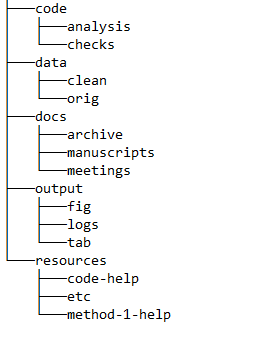

```r
knitr::include_graphics(here("docs", "folder-tree.png"))
```

### #2 - Objects

A variety of notes on objects

- *My non-computer scientist opinion*: The term **object** is a catch-all for a ‘thing’ that is created. Objects are usually one kind of class and can include many different pieces (Wikipedia says “a combination of variables, functions, and data structures”).
  - To me this means that datasets are objects – their class is a dataset, and they contain variables.
  - Here are the objects that I have come across the most in R:
    - matrices
    - vectors
    - dataframes/datasets and [tibbles](https://tibble.tidyverse.org/reference/tbl_df-class.html) - a sub-type of dataframe. “tibbles are lazy and surly: they do less and complain more than base data.frames. This forces problems to be tackled earlier and more explicitly, typically leading to code that is more expressive and robust”
      - within these objects, each variable will have its own class. these can be:
        - numeric (numbers with decimals, somtimes called a double, I think)
        - integer (numbers without decimals)
        - character (words)
        - factor (numbers with assigned labels)
        - lists (yes, you can have a list-column – very meta. also very useful sometimes!)
    - lists
      - one of the objects with the biggest learning curve (I think)
      - lists hold multiple things – those things can be dataframes, vectors, etc.
      - understanding lists and how R works with them is a whole new world – but is rapidly changing, so I’m hesitant to do too much with it now.
      - in my experience, iterating through a list is R’s alternative to for loops (though you can still write for loops!). However, I’ve seen on twitter that new things are coming down the pipeline.
    - regression objects (which are also kind of lists)
    - ggplot objects (which are also kind of lists; I’ve not used them much)

#### Vectors

```r
# Vectors -----------------------------------------------------------------
# also scalars/values

# I like to use scalars to make my code more readable
# for example:
numerator <- 124
denominator <- 45

(ratio <- numerator/denominator) # enclosing in () just makes it print automatically
```

```
## [1] 2.755556
```

```r
numerator/denominator
```

```
## [1] 2.755556
```

```r
# I tend to do things like number of iterations, simulation size, etc. as scalars


# vectors include multiple things
people <- c("antoni", "karamo", "bobby", "tan", "jonathan")
names(people) <- c("first", "second", "third", "fourth", "fifth")
people
```

```
##      first     second      third     fourth      fifth
##   "antoni"   "karamo"    "bobby"      "tan" "jonathan"
```

```r
job <- c("food", "life", "home", "clothes", "hair")
age <- c(36, 39, 38, 37, 33)

# can combine them together using cbind()
queerEye <- cbind(people, job, age)
# rbind stacks by rows
# cbind appends columns
# take a look - note that the names are now rownames of the matrix!
# personally i never rely on rownames
# in dataframes, whenever you reorder, the rownames get reset
# very dangerous
# ALWAYS better to use an explicit ID variable
```

#### Matrices

```r
# Matrices ----------------------------------------------------------------

# here I am manually inputting the rows and columns of a matrix
# and i specify how many rows and columns that matrix has
# byrow means that i am inputting the data in row-wise order...
# so once 4 numbers have been input, that's the end of the first row, etc.
aMatrix <- matrix(c(1,2,3,4,
                    5,6,7,8,
                    9, 10, 11, 12),
                  nrow=3, ncol=4,
                  byrow=TRUE)

# access things within a matrix using the indices
# first element is the rows, second is the columns
tmp <- aMatrix[1,1] # first row, first column
aMatrix[,2] # whole second column
```

```
## [1]  2  6 10
```

```r
aMatrix[c(1,3),] # first and third rows, all columns
```

```
##      [,1] [,2] [,3] [,4]
## [1,]    1    2    3    4
## [2,]    9   10   11   12
```

```r
# you can also assign these to new objects to use them again
names(aMatrix) # has no names :(
```

[output not shown]

```r
colnames(aMatrix) <- c("v1", "v2", "v3", "v4")

# now I can use the names to ask for things
aMatrix[2, c("v3", "v4")]
```

```
## v3 v4
##  7  8
```

```r
# again, taking the time to name things makes code much more reasonable


# you can also change a dataframe into a matrix
aLittleDF <- tribble(~col1, ~col2, ~col3,
                     "hi", 1, 2,
                     "hello", 3, 4,
                     "bonjour", 5, 6)

# note that because there are characters in one of the columns, all of the columns are matrices
DFtoMatrix <- as.matrix(aLittleDF)
# can also make a matrix into a dataframe using as.data.frame()
```

#### Dataframes / Tibbles

```r
# Dataframes / tibbles ----------------------------------------------------

data(diamonds)

# class() tells you what it is
class(diamonds)
```

```
## [1] "tbl_df"     "tbl"        "data.frame"
```

```r
# this is a tibble - type of dataframe
#?diamonds

# str() gives you the internal structure of a given object
str(diamonds)
```

```
## tibble [53,940 x 10] (S3: tbl_df/tbl/data.frame)
##  $ carat  : num [1:53940] 0.23 0.21 0.23 0.29 0.31 0.24 0.24 0.26 0.22 0.23 ...
##  $ cut    : Ord.factor w/ 5 levels "Fair"<"Good"<..: 5 4 2 4 2 3 3 3 1 3 ...
##  $ color  : Ord.factor w/ 7 levels "D"<"E"<"F"<"G"<..: 2 2 2 6 7 7 6 5 2 5 ...
##  $ clarity: Ord.factor w/ 8 levels "I1"<"SI2"<"SI1"<..: 2 3 5 4 2 6 7 3 4 5 ...
##  $ depth  : num [1:53940] 61.5 59.8 56.9 62.4 63.3 62.8 62.3 61.9 65.1 59.4 ...
##  $ table  : num [1:53940] 55 61 65 58 58 57 57 55 61 61 ...
##  $ price  : int [1:53940] 326 326 327 334 335 336 336 337 337 338 ...
##  $ x      : num [1:53940] 3.95 3.89 4.05 4.2 4.34 3.94 3.95 4.07 3.87 4 ...
##  $ y      : num [1:53940] 3.98 3.84 4.07 4.23 4.35 3.96 3.98 4.11 3.78 4.05 ...
##  $ z      : num [1:53940] 2.43 2.31 2.31 2.63 2.75 2.48 2.47 2.53 2.49 2.39 ...
```

```r
# there are 10 variables here - numeric, integer, and ordered factor variables

# Factor variables these are perhaps the most different from other softwares. Check out the forcats cheat sheet from R studio for more info: https://rstudio.com/resources/cheatsheets/
# we'll do more on factors within data management
# this actually shows us the ORDERING of the levels
str(diamonds$cut)
```

```
##  Ord.factor w/ 5 levels "Fair"<"Good"<..: 5 4 2 4 2 3 3 3 1 3 ...
```

```r
xtabs(~cut, data=diamonds)
```

```
## cut
##      Fair      Good Very Good   Premium     Ideal
##      1610      4906     12082     13791     21551
```